# Weather and Corn Yield Regressions

## Assignment

### Question 1a

Extract Winneshiek County corn yields, fit a linear time trend, make a plot. Is there a significant time trend?

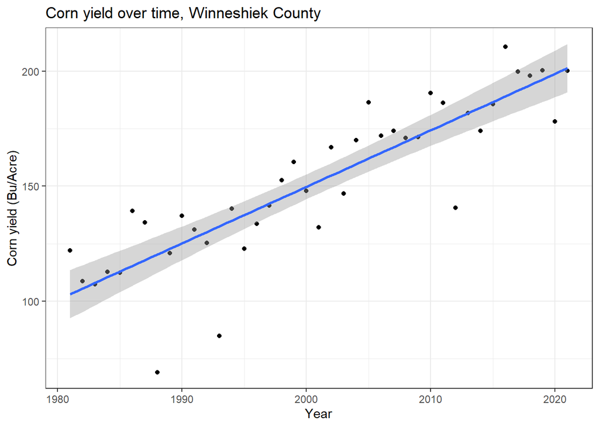

```r
winnecorn <- cornyields[cornyields$county_ansi == 191,]

ggplot(winnecorn, mapping = aes(x = year, y = yield)) +
  geom_point() +
  theme_bw() +
  labs(x = "Year", y = "Corn yield (Bu/Acre)") +
  ggtitle("Corn yield over time, Winneshiek County") +
  geom_smooth(method = lm)
```

### Answer 1a

There is a positive correlation between corn `yield` and `year` in Winneshiek County, which illustrates that corn yield at a Bu/acre metric has increased over time from 1981 to 2021.

### Question 1b

Fit a quadratic time trend (i.e., year + year^2) and make a plot. Is there evidence for slowing yield growth?

```r
winnecorn$yearsq <- winnecorn$year^2

lm_cornyieldquad <- lm(yield ~ year + yearsq, winnecorn)
summary(lm_cornyieldquad)
```

```
##
## Call:
## lm(formula = yield ~ year + yearsq, data = winnecorn)
##
## Residuals:
##     Min      1Q  Median      3Q     Max
## -51.384  -3.115   1.388   9.743  25.324
##
## Coefficients:
##               Estimate Std. Error t value Pr(>|t|)
## (Intercept)  2.583e+04  8.580e+04   0.301    0.765
## year        -2.812e+01  8.576e+01  -0.328    0.745
## yearsq       7.641e-03  2.143e-02   0.357    0.723
##
## Residual standard error: 17.17 on 38 degrees of freedom
## Multiple R-squared:  0.7559, Adjusted R-squared:  0.7431
## F-statistic: 58.84 on 2 and 38 DF,  p-value: 2.311e-12
```

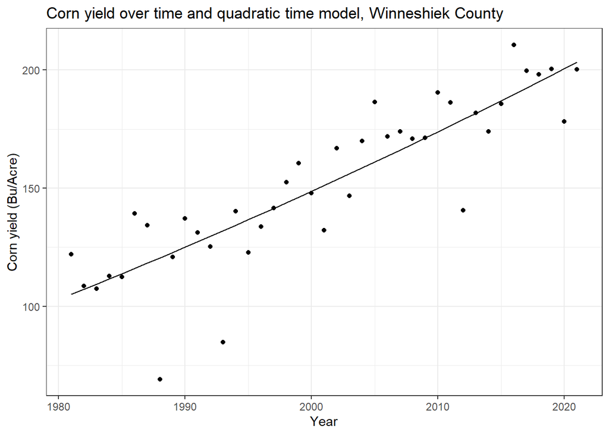

```r
winnecorn$fitted <- lm_cornyieldquad$fitted.values

ggplot(winnecorn) +
  geom_point(mapping = aes(x = year, y = yield)) +
  geom_line(mapping = aes(x = year, y = fitted)) +
  theme_bw() +
  ggtitle("Corn yield over time and quadratic time model, Winneshiek County") +
  labs(x = "Year", y = "Corn yield (Bu/Acre)")
```

### Answer 1b

There is not evidence of a slowing yield growth in our quadratic time trend. Our `year` variable has a negative intercept while our `years^2` variable has a positive intercept. This would suggest a potential increasing `yield` growth over time. However, both time variables in our model are insignificant (>0.7, in this case), so we cannot conclusively say the yield growth rate is decreasing or increasing over time.

### Question 2 Time Series

Let’s analyze the relationship between temperature and yields for the Winneshiek County time series. Use data on yield and summer avg Tmax. Is adding year or Tmax^2 to your model helpful? Make a plot and interpret the results.

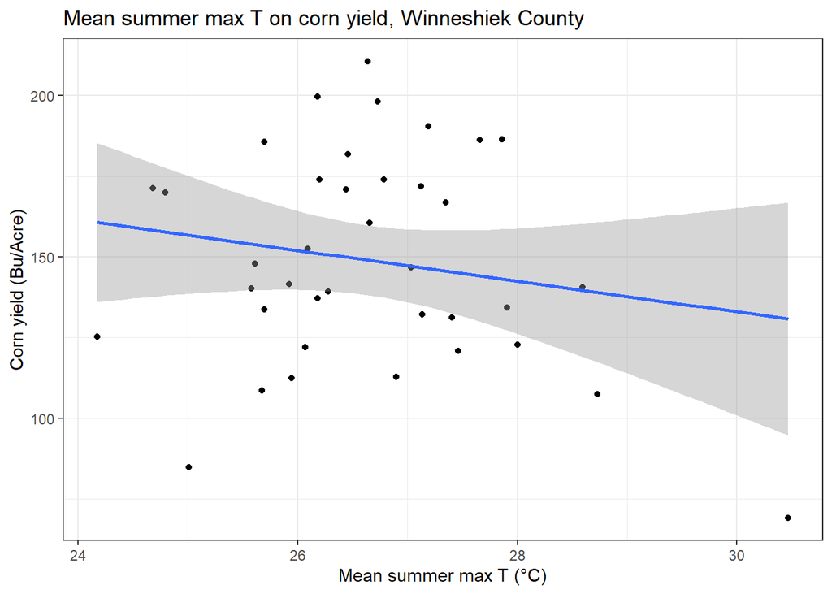

```r
winnecornsummer <- inner_join(winnesummer, winnecorn, by="year")

#Analyzing with just yield and Tmax


ggplot(winnecornsummer, mapping = aes(x = meantmax, y = yield)) +
  geom_point() +
  theme_bw() +
  labs(x = "Mean summer max T (°C)", y = "Corn yield (Bu/Acre)") +
  ggtitle("Mean summer max T on corn yield, Winneshiek County") +
  geom_smooth(method = lm)
```

```r
#Linear Models
#Linear model of just yield and mean Tmax
lm_cornsummertmax <- lm(yield ~ meantmax, winnecornsummer)
summary(lm_cornsummertmax)
```

```
##
## Call:
## lm(formula = yield ~ meantmax, data = winnecornsummer)
##
## Residuals:
##    Min     1Q Median     3Q    Max
## -71.96 -19.85  -3.19  24.64  61.72
##
## Coefficients:
##             Estimate Std. Error t value Pr(>|t|)
## (Intercept)  275.876    118.335   2.331   0.0255 *
## meantmax      -4.763      4.438  -1.073   0.2902
## ---
## Signif. codes:  0 '***' 0.001 '**' 0.01 '*' 0.05 '.' 0.1 ' ' 1
##
## Residual standard error: 32.88 on 36 degrees of freedom
## Multiple R-squared:  0.03101,    Adjusted R-squared:  0.004098
## F-statistic: 1.152 on 1 and 36 DF,  p-value: 0.2902
```

```r
#Linear model of yield and mean Tmax + year
lm_cornsummertmax1 <- lm(yield ~ year + meantmax, winnecornsummer)
summary(lm_cornsummertmax1)
```

```
##
## Call:
## lm(formula = yield ~ year + meantmax, data = winnecornsummer)
##
## Residuals:
##     Min      1Q  Median      3Q     Max
## -53.071  -7.269   2.271   9.935  27.505
##
## Coefficients:
##              Estimate Std. Error t value Pr(>|t|)
## (Intercept) -4791.774    513.812  -9.326 5.10e-11 ***
## year            2.514      0.253   9.934 1.01e-11 ***
## meantmax       -3.201      2.308  -1.387    0.174
## ---
## Signif. codes:  0 '***' 0.001 '**' 0.01 '*' 0.05 '.' 0.1 ' ' 1
##
## Residual standard error: 17.06 on 35 degrees of freedom
## Multiple R-squared:  0.7463, Adjusted R-squared:  0.7318
## F-statistic: 51.48 on 2 and 35 DF,  p-value: 3.761e-11
```

```r
#Quadratic Models
#Quadratic model using year, year^2, mean Tmax, and mean Tmax^2
winnecornsummer$meantxmaxsq <- winnecornsummer$meantmax^2
lm_cornyieldsummertquad <- lm(yield ~ year + yearsq + meantmax + meantxmaxsq, winnecornsummer)
summary(lm_cornyieldsummertquad)
```

```
##
## Call:
## lm(formula = yield ~ year + yearsq + meantmax + meantxmaxsq,
##     data = winnecornsummer)
##
## Residuals:
##     Min      1Q  Median      3Q     Max
## -43.488  -5.935   0.565   9.052  27.192
##
## Coefficients:
##               Estimate Std. Error t value Pr(>|t|)
## (Intercept)  7.437e+04  8.687e+04   0.856 0.398150
## year        -7.929e+01  8.684e+01  -0.913 0.367834
## yearsq       2.041e-02  2.172e-02   0.940 0.354109
## meantmax     2.050e+02  5.323e+01   3.850 0.000514 ***
## meantxmaxsq -3.856e+00  9.845e-01  -3.916 0.000426 ***
## ---
## Signif. codes:  0 '***' 0.001 '**' 0.01 '*' 0.05 '.' 0.1 ' ' 1
##
## Residual standard error: 14.29 on 33 degrees of freedom
## Multiple R-squared:  0.8322, Adjusted R-squared:  0.8118
## F-statistic:  40.9 on 4 and 33 DF,  p-value: 2.394e-12
```

```r
winnecornsummer$fitted <- lm_cornyieldsummertquad$fitted.values
#Quadratic model using year, mean Tmax, and mean Tmax^2
lm_cornyieldsummertquad2 <- lm(yield ~ year + meantmax + meantxmaxsq, winnecornsummer)
summary(lm_cornyieldsummertquad2)
```

```
##
## Call:
## lm(formula = yield ~ year + meantmax + meantxmaxsq, data = winnecornsummer)
##
## Residuals:
##     Min      1Q  Median      3Q     Max
## -44.683  -5.427   1.214   8.943  25.127
##
## Coefficients:
##               Estimate Std. Error t value Pr(>|t|)
## (Intercept) -7280.2956   755.2808  -9.639 2.96e-11 ***
## year            2.3286     0.2166  10.752 1.77e-12 ***
## meantmax      208.9004    52.9773   3.943 0.000381 ***
## meantxmaxsq    -3.9259     0.9799  -4.006 0.000318 ***
## ---
## Signif. codes:  0 '***' 0.001 '**' 0.01 '*' 0.05 '.' 0.1 ' ' 1
##
## Residual standard error: 14.27 on 34 degrees of freedom
## Multiple R-squared:  0.8277, Adjusted R-squared:  0.8125
## F-statistic: 54.43 on 3 and 34 DF,  p-value: 4.538e-13
```

```r
winnecornsummer$fitted2 <- lm_cornyieldsummertquad2$fitted.values

#AIC
AIC(lm_cornsummertmax, lm_cornsummertmax1, lm_cornyieldsummertquad, lm_cornyieldsummertquad2)
```

```
##                          df      AIC
## lm_cornsummertmax         3 377.2529
## lm_cornsummertmax1        4 328.3276
## lm_cornyieldsummertquad   6 316.6304
## lm_cornyieldsummertquad2  5 315.6342
```

[figure not shown]

```r
p1 <- ggplot(winnecornsummer) +
      geom_point(mapping = aes(x = year, y = yield, col="Actual")) +
      geom_line(mapping = aes(x = year, y = fitted2, col="Fitted")) +
      theme_bw() +
      ggtitle("Corn yield over time, quadratic time model, Winneshiek County") +
      labs(x = "Year", y = "Corn yield (Bu/Acre)")

p2 <- ggplot(winnecornsummer) +
      geom_point(mapping = aes(x = meantmax, y = yield, col="Actual")) +
      geom_line(mapping = aes(x = meantmax, y = fitted2, col="Fitted")) +
      theme_bw() +
      ggtitle("Corn yield over summer max temperature, and quadratic temperature model, Winneshiek County") +
      labs(x = "Mean summer max T (°C) squared", y = "Corn yield (Bu/Acre)")
grid.arrange(p1, p2)
```

### Answer 2

In our quadratic model using `year`, `year^2`, `mean summer max temperature`, and `mean summer max temperature^2`, both temperature predictors are significant (p<0.001), while the year predictors are insignificant. In the end, our best model used `year`, `mean summer max temperature`, and `mean summer max temperature^2` as predictors were all highly significant (p<0.001) with an AIC of 315.63. This suggests that an optimal temperature range modeled with extreme environmental disturbance years best predicts a year’s corn yield.

### Question 3 Cross-Section

Analyze the relationship between temperature and yield across all counties in 2018. Is there a relationship? Interpret the results.

```r
corn2018 <- cornyields[cornyields$year == 2018,]
corn2018$countyfp <- as.factor(corn2018$county_ansi)

summer2018 <- tmaxdf %>%
  filter(doy >= 152 & doy <= 243) %>%
  filter(year == 2018) %>%
  group_by(year, countyfp) %>%
  summarize(meantmaxsum = mean(tmax))
#Just using first 59 days in 2018 and not end of 2017
winter2018 <- tmaxdf %>%
  filter((doy <= 59) & !is.na(tmax)) %>%
  filter(year == 2018) %>%
  group_by(year, countyfp) %>%
  summarize(meantmaxwin = mean(tmax))
corn2018 <- left_join(corn2018, summer2018, keep=F, by="countyfp")
corn2018 <- left_join(corn2018, winter2018, keep=F, by="countyfp")
corn2018$meantmaxsumsq <- corn2018$meantmaxsum^2
corn2018$meantmaxwinsq <- corn2018$meantmaxwin^2

#Linear models analyzing summer, winter, and both combined
lm_2018cornsummer <- lm(yield ~ meantmaxsum, corn2018)
summary(lm_2018cornsummer)
```

```
##
## Call:
## lm(formula = yield ~ meantmaxsum, data = corn2018)
##
## Residuals:
##     Min      1Q  Median      3Q     Max
## -42.983 -15.041   0.955  16.795  31.999
##
## Coefficients:
##             Estimate Std. Error t value Pr(>|t|)
## (Intercept)  312.466     63.387   4.929 3.69e-06 ***
## meantmaxsum   -4.216      2.241  -1.882   0.0631 .
## ---
## Signif. codes:  0 '***' 0.001 '**' 0.01 '*' 0.05 '.' 0.1 ' ' 1
##
## Residual standard error: 19.64 on 91 degrees of freedom
## Multiple R-squared:  0.03745,    Adjusted R-squared:  0.02687
## F-statistic: 3.541 on 1 and 91 DF,  p-value: 0.06308
```

```r
lm_2018cornwinter <- lm(yield ~ meantmaxwin, corn2018)
summary(lm_2018cornwinter)
```

```
##
## Call:
## lm(formula = yield ~ meantmaxwin, data = corn2018)
##
## Residuals:
##     Min      1Q  Median      3Q     Max
## -43.600 -13.403  -0.109  17.861  32.699
##
## Coefficients:
##             Estimate Std. Error t value Pr(>|t|)
## (Intercept) 192.8934     3.5487  54.356   <2e-16 ***
## meantmaxwin  -0.1475     1.1746  -0.126      0.9
## ---
## Signif. codes:  0 '***' 0.001 '**' 0.01 '*' 0.05 '.' 0.1 ' ' 1
##
## Residual standard error: 20.01 on 91 degrees of freedom
## Multiple R-squared:  0.0001732,  Adjusted R-squared:  -0.01081
## F-statistic: 0.01577 on 1 and 91 DF,  p-value: 0.9004
```

```r
lm_2018cornall <- lm(yield ~ meantmaxsum + meantmaxwin, corn2018)
summary(lm_2018cornall)
```

```
##
## Call:
## lm(formula = yield ~ meantmaxsum + meantmaxwin, data = corn2018)
##
## Residuals:
##     Min      1Q  Median      3Q     Max
## -40.172 -11.908  -0.057  14.654  32.094
##
## Coefficients:
##             Estimate Std. Error t value Pr(>|t|)
## (Intercept)  748.803    135.388   5.531 3.09e-07 ***
## meantmaxsum  -18.912      4.605  -4.107 8.80e-05 ***
## meantmaxwin    8.501      2.368   3.590 0.000539 ***
## ---
## Signif. codes:  0 '***' 0.001 '**' 0.01 '*' 0.05 '.' 0.1 ' ' 1
##
## Residual standard error: 18.47 on 90 degrees of freedom
## Multiple R-squared:  0.158,  Adjusted R-squared:  0.1393
## F-statistic: 8.444 on 2 and 90 DF,  p-value: 0.0004356
```

```r
#Quadratic models analyzing summer, winter, and both combined
lm_2018cornsummer2 <- lm(yield ~ meantmaxsum + meantmaxsumsq, corn2018)
summary(lm_2018cornsummer2)
```

```
##
## Call:
## lm(formula = yield ~ meantmaxsum + meantmaxsumsq, data = corn2018)
##
## Residuals:
##     Min      1Q  Median      3Q     Max
## -44.221 -15.399   5.007  14.541  30.879
##
## Coefficients:
##                Estimate Std. Error t value Pr(>|t|)
## (Intercept)   -5501.602   1860.830  -2.957  0.00397 **
## meantmaxsum     406.789    131.493   3.094  0.00263 **
## meantmaxsumsq    -7.256      2.321  -3.126  0.00239 **
## ---
## Signif. codes:  0 '***' 0.001 '**' 0.01 '*' 0.05 '.' 0.1 ' ' 1
##
## Residual standard error: 18.75 on 90 degrees of freedom
## Multiple R-squared:  0.1317, Adjusted R-squared:  0.1124
## F-statistic: 6.827 on 2 and 90 DF,  p-value: 0.001736
```

```r
lm_2018cornwinter2 <- lm(yield ~ meantmaxwin + meantmaxwinsq, corn2018)
summary(lm_2018cornwinter2)
```

```
##
## Call:
## lm(formula = yield ~ meantmaxwin + meantmaxwinsq, data = corn2018)
##
## Residuals:
##     Min      1Q  Median      3Q     Max
## -49.631 -11.680   2.981  14.631  33.940
##
## Coefficients:
##               Estimate Std. Error t value Pr(>|t|)
## (Intercept)   187.0200     3.5855  52.161  < 2e-16 ***
## meantmaxwin   -12.3404     3.1936  -3.864 0.000210 ***
## meantmaxwinsq  -2.6303     0.6479  -4.060 0.000105 ***
## ---
## Signif. codes:  0 '***' 0.001 '**' 0.01 '*' 0.05 '.' 0.1 ' ' 1
##
## Residual standard error: 18.5 on 90 degrees of freedom
## Multiple R-squared:  0.1549, Adjusted R-squared:  0.1361
## F-statistic:  8.25 on 2 and 90 DF,  p-value: 0.0005131
```

```r
lm_2018cornall2 <- lm(yield ~ meantmaxsum + meantmaxwin + meantmaxsumsq + meantmaxwinsq, corn2018)
summary(lm_2018cornall2)
```

```
##
## Call:
## lm(formula = yield ~ meantmaxsum + meantmaxwin + meantmaxsumsq +
##     meantmaxwinsq, data = corn2018)
##
## Residuals:
##     Min      1Q  Median      3Q     Max
## -44.886  -9.707   0.920  11.477  26.037
##
## Coefficients:
##                 Estimate Std. Error t value Pr(>|t|)
## (Intercept)   -6783.3522  2454.3346  -2.764  0.00696 **
## meantmaxsum     518.2609   176.0455   2.944  0.00414 **
## meantmaxwin       9.8176     5.6831   1.727  0.08759 .
## meantmaxsumsq    -9.5599     3.1494  -3.035  0.00316 **
## meantmaxwinsq    -0.2643     0.8728  -0.303  0.76276
## ---
## Signif. codes:  0 '***' 0.001 '**' 0.01 '*' 0.05 '.' 0.1 ' ' 1
##
## Residual standard error: 16.62 on 88 degrees of freedom
## Multiple R-squared:  0.3331, Adjusted R-squared:  0.3028
## F-statistic: 10.99 on 4 and 88 DF,  p-value: 2.832e-07
```

```r
AIC(lm_2018cornsummer, lm_2018cornsummer2, lm_2018cornwinter, lm_2018cornwinter2, lm_2018cornall, lm_2018cornall2)
```

```
##                    df      AIC
## lm_2018cornsummer   3 821.6913
## lm_2018cornsummer2  4 814.1046
## lm_2018cornwinter   3 825.2250
## lm_2018cornwinter2  4 811.5862
## lm_2018cornall      4 811.2477
## lm_2018cornall2     6 793.5592
```

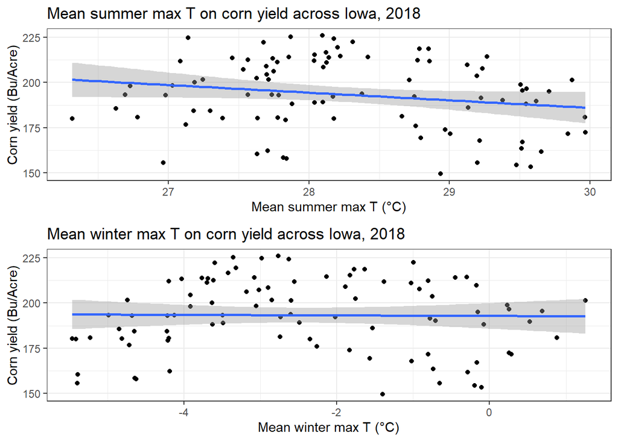

```r
p1 <- ggplot(corn2018, mapping = aes(x = meantmaxsum, y = yield)) +
      geom_point() +
      theme_bw() +
      labs(x = "Mean summer max T (°C)", y = "Corn yield (Bu/Acre)") +
      ggtitle("Mean summer max T on corn yield across Iowa, 2018") +
      geom_smooth(method = lm)

p2 <- ggplot(corn2018, mapping = aes(x = meantmaxwin, y = yield)) +
      geom_point() +
      theme_bw() +
      labs(x = "Mean winter max T (°C)", y = "Corn yield (Bu/Acre)") +
      ggtitle("Mean winter max T on corn yield across Iowa, 2018") +
      geom_smooth(method = lm)
grid.arrange(p1, p2)
```

### Question 4 Panel

One way to leverage multiple time series is to group all data into what is called a “panel” regression. Convert the county ID code (“countyfp” or “county_ansi”) into factor using as.factor, then include this variable in a regression using all counties’ yield and summer temperature data. How does the significance of your temperature coefficients (Tmax, Tmax^2) change? Make a plot comparing actual and fitted yields and interpret the results of your model.

```r
cornyields$countyfp <- as.factor(cornyields$county_ansi)
allsummer <- tmaxdf %>%
  filter(doy >= 152 & doy <= 243) %>%
  group_by(year, countyfp) %>%
  summarize(meantmax = mean(tmax))
allcorn <- left_join(cornyields, allsummer, by=c("countyfp", "year")) %>%
  na.omit(.)
allcorn$meantmaxsq <- allcorn$meantmax^2

lm_allcorn <- lm(yield ~ countyfp + meantmax + meantmaxsq, allcorn)
summary(lm_allcorn)
```

```
##
## Call:
## lm(formula = yield ~ countyfp + meantmax + meantmaxsq, data = allcorn)
##
## Residuals:
##     Min      1Q  Median      3Q     Max
## -95.088 -21.438  -3.026  23.570  77.941
##
## Coefficients:
##               Estimate Std. Error t value Pr(>|t|)
## (Intercept) -2102.2327   139.2946 -15.092  < 2e-16 ***
## countyfp3      -4.5577     7.0388  -0.648 0.517347
## countyfp5       1.9797     7.0743   0.280 0.779612
## countyfp7     -19.1369     7.0864  -2.701 0.006955 **
## countyfp9       4.3024     7.0416   0.611 0.541240
## countyfp11      6.2752     7.0459   0.891 0.373195
## countyfp13      6.2028     7.0520   0.880 0.379147
## countyfp15     14.3129     7.0414   2.033 0.042157 *
## countyfp17     10.2595     7.0568   1.454 0.146076
## countyfp19      6.6549     7.0596   0.943 0.345912
## countyfp21      7.5427     7.0503   1.070 0.284760
## countyfp23      8.0045     7.0493   1.135 0.256242
## countyfp25      9.3627     7.0468   1.329 0.184048
## countyfp27      8.8039     7.0426   1.250 0.211348
## countyfp29      6.0858     7.0389   0.865 0.387315
## countyfp31     14.9921     7.0443   2.128 0.033381 *
## countyfp33      3.7400     7.0668   0.529 0.596677
## countyfp35     12.8689     7.0455   1.827 0.067848 .
## countyfp37      1.3837     7.0714   0.196 0.844876
## countyfp39    -24.9874     7.0863  -3.526 0.000427 ***
## countyfp41      5.5213     7.0521   0.783 0.433716
## countyfp43      7.9986     7.0648   1.132 0.257632
## countyfp45      9.7142     7.0455   1.379 0.168043
## countyfp47      5.5829     7.0436   0.793 0.428054
## countyfp49     10.5962     7.0391   1.505 0.132323
## countyfp51    -14.6474     7.0887  -2.066 0.038872 *
## countyfp53    -16.7641     7.0865  -2.366 0.018051 *
## countyfp55      8.6421     7.0667   1.223 0.221435
## countyfp57     10.8382     7.0391   1.540 0.123719
## countyfp59      2.0837     7.0635   0.295 0.768011
```

[output cut: 62 more lines]

```
## countyfp185   -22.9077     7.0863  -3.233 0.001237 **
## countyfp187    13.1211     7.0472   1.862 0.062700 .
## countyfp189     7.5593     7.0757   1.068 0.285441
## countyfp191     4.0826     7.0867   0.576 0.564584
## countyfp193     2.3508     7.0395   0.334 0.738436
## countyfp195     5.9103     7.0954   0.833 0.404908
## countyfp197    10.4404     7.0518   1.481 0.138817
## meantmax      167.9699     9.8950  16.975  < 2e-16 ***
## meantmaxsq     -3.1324     0.1758 -17.820  < 2e-16 ***
## ---
## Signif. codes:  0 '***' 0.001 '**' 0.01 '*' 0.05 '.' 0.1 ' ' 1
##
## Residual standard error: 30.68 on 3647 degrees of freedom
## Multiple R-squared:  0.2585, Adjusted R-squared:  0.2382
## F-statistic: 12.71 on 100 and 3647 DF,  p-value: < 2.2e-16
```

```r
AIC(lm_allcorn)
```

```
## [1] 36401.75
```

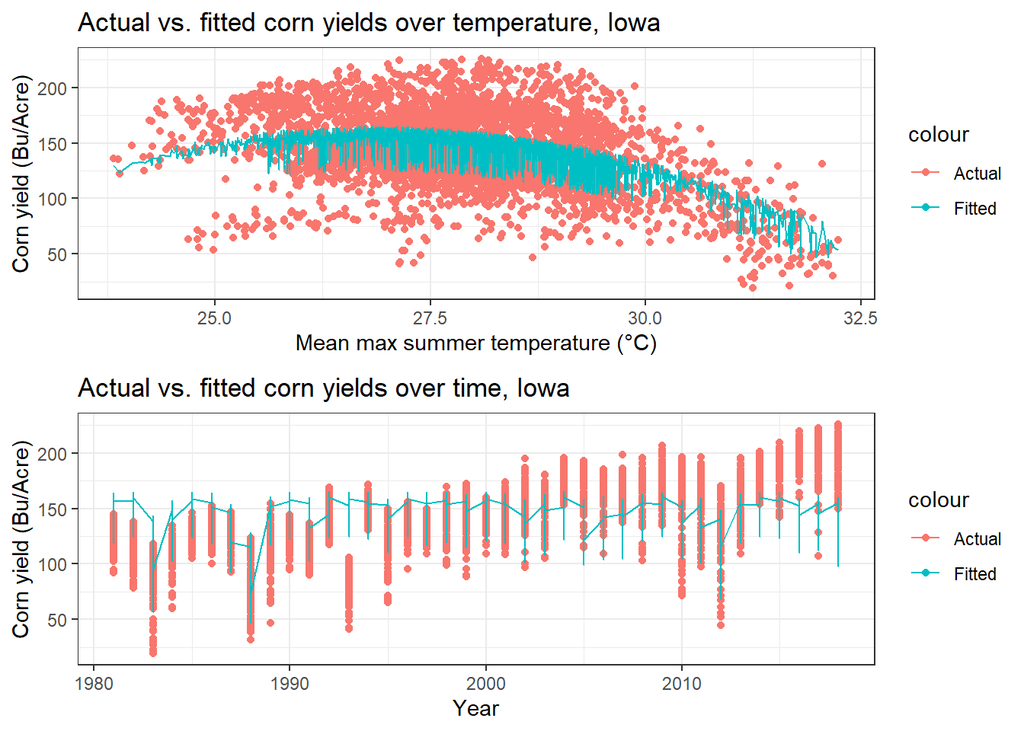

```r
allcorn$fitted <- lm_allcorn$fitted.values

p1 <- ggplot(allcorn) +
      geom_point(mapping = aes(x = meantmax, y = yield, col="Actual")) +
      geom_line(mapping = aes(x = meantmax, y = fitted, col="Fitted")) +
      theme_bw() +
      labs(x = "Mean max summer temperature (°C)", y = "Corn yield (Bu/Acre)") +
      ggtitle("Actual vs. fitted corn yields over temperature, Iowa")

p2 <- ggplot(allcorn) +
      geom_point(mapping = aes(x = year, y = yield, col="Actual")) +
      geom_line(mapping = aes(x = year, y = fitted, col="Fitted")) +
      theme_bw() +
      labs(x = "Year", y = "Corn yield (Bu/Acre)") +
      ggtitle("Actual vs. fitted corn yields over time, Iowa")
grid.arrange(p1, p2)
```

### Question 5 Soybeans

Download NASS data on soybean yields and explore either a time series relationship for a given county, the cross-sectional relationship for a given year, or a panel across all counties and years.

```r
# parameters to query on
params <- list(commodity_desc = "SOYBEANS", prodn_practice_desc = "ALL PRODUCTION PRACTICES", year__GE = 1981, state_alpha = "IA")

# download
soyyieldsall <- nassqs_yields(params)
```

[figure not shown]

```r
soyyieldsall$county_ansi <- as.numeric(soyyieldsall$county_ansi)
soyyieldsall$yield <- as.numeric(soyyieldsall$Value)

# clean and filter this dataset
soyyields <- select(soyyieldsall, county_ansi, county_name, yield, year) %>%
  filter(!is.na(county_ansi) & !is.na(yield))
soyyields <- tibble(cornyields)

#Time-series analysis of Buena Vista County
bvsummer <- tmaxdf %>%
  filter(countyfp==21 & doy >= 152 & doy <= 243) %>%
  group_by(year) %>%
  summarize(meantmax = mean(tmax))
bvwinter <- tmaxdf %>%
  filter(countyfp==21 & (doy <= 59 | doy >= 335) & !is.na(tmax)) %>%
  group_by(year) %>%
  summarize(meantmax = mean(tmax))

bvsoy <- soyyields[soyyields$county_ansi == 21,]

bvsoysummer <- inner_join(bvsummer, bvsoy, by="year")

#Visualization

p1 <- ggplot(bvsoysummer, mapping = aes(x = year, y = yield)) +
      geom_point() +
      theme_bw() +
      labs(x = "Year", y = "Soybean yield (Bu/Acre)") +
      ggtitle("Soybean yield over time, Buena Vista County") +
      geom_smooth(method = lm)

p2 <- ggplot(bvsoysummer, mapping = aes(x = meantmax, y = yield)) +
      geom_point() +
      theme_bw() +
      labs(x = "Mean summer max T (°C)", y = "Soybean yield (Bu/Acre)") +
      ggtitle("Mean summer max T on soybean yield, Buena Vista County") +
      geom_smooth(method = lm)
grid.arrange(p1,p2)
```

```r
#Linear Models
#Linear model of just yield and mean Tmax
lm_bvsummertmax <- lm(yield ~ meantmax, bvsoysummer)
summary(lm_bvsummertmax)
```

```
##
## Call:
## lm(formula = yield ~ meantmax, data = bvsoysummer)
##
## Residuals:
##     Min      1Q  Median      3Q     Max
## -81.407 -19.107   0.629  25.805  52.820
##
## Coefficients:
##             Estimate Std. Error t value Pr(>|t|)
## (Intercept)  304.919    114.594   2.661   0.0116 *
## meantmax      -5.590      4.165  -1.342   0.1879
## ---
## Signif. codes:  0 '***' 0.001 '**' 0.01 '*' 0.05 '.' 0.1 ' ' 1
##
## Residual standard error: 30.34 on 36 degrees of freedom
## Multiple R-squared:  0.04765,    Adjusted R-squared:  0.0212
## F-statistic: 1.801 on 1 and 36 DF,  p-value: 0.1879
```

```r
#Linear model of yield and mean Tmax + year
lm_bvsummertmax1 <- lm(yield ~ year + meantmax, bvsoysummer)
summary(lm_bvsummertmax1)
```

```
##
## Call:
## lm(formula = yield ~ year + meantmax, data = bvsoysummer)
##
## Residuals:
##     Min      1Q  Median      3Q     Max
## -65.684  -7.254   3.237   9.785  25.280
##
## Coefficients:
##               Estimate Std. Error t value Pr(>|t|)
## (Intercept) -4177.5319   515.7875  -8.099 1.55e-09 ***
## year            2.2329     0.2549   8.760 2.40e-10 ***
## meantmax       -4.9434     2.3653  -2.090    0.044 *
## ---
## Signif. codes:  0 '***' 0.001 '**' 0.01 '*' 0.05 '.' 0.1 ' ' 1
##
## Residual standard error: 17.22 on 35 degrees of freedom
## Multiple R-squared:  0.7017, Adjusted R-squared:  0.6847
## F-statistic: 41.17 on 2 and 35 DF,  p-value: 6.399e-10
```

```r
#Quadratic Models
#Quadratic model using year, year^2, mean Tmax, and mean Tmax^2
bvsoysummer$yearsq <- bvsoysummer$year^2
bvsoysummer$meantxmaxsq <- bvsoysummer$meantmax^2
lm_soyyieldsummertquad <- lm(yield ~ year + yearsq + meantmax + meantxmaxsq, bvsoysummer)
summary(lm_soyyieldsummertquad)
```

```
##
## Call:
## lm(formula = yield ~ year + yearsq + meantmax + meantxmaxsq,
##     data = bvsoysummer)
##
## Residuals:
##     Min      1Q  Median      3Q     Max
## -63.108  -8.291   3.306  11.658  24.984
##
## Coefficients:
##               Estimate Std. Error t value Pr(>|t|)
## (Intercept)  3.421e+03  1.065e+05   0.032    0.975
## year        -6.331e+00  1.065e+02  -0.059    0.953
## yearsq       2.133e-03  2.662e-02   0.080    0.937
## meantmax     6.784e+01  8.137e+01   0.834    0.410
## meantxmaxsq -1.325e+00  1.480e+00  -0.895    0.377
##
## Residual standard error: 17.52 on 33 degrees of freedom
## Multiple R-squared:  0.709,  Adjusted R-squared:  0.6737
## F-statistic:  20.1 on 4 and 33 DF,  p-value: 1.813e-08
```

```r
bvsoysummer$fitted <- lm_soyyieldsummertquad$fitted.values
#Quadratic model using year, mean Tmax, and mean Tmax^2
lm_soyyieldsummertquad2 <- lm(yield ~ year + meantmax + meantxmaxsq, bvsoysummer)
summary(lm_soyyieldsummertquad2)
```

```
##
## Call:
## lm(formula = yield ~ year + meantmax + meantxmaxsq, data = bvsoysummer)
##
## Residuals:
##     Min      1Q  Median      3Q     Max
## -63.227  -8.546   3.184  11.536  24.829
##
## Coefficients:
##               Estimate Std. Error t value Pr(>|t|)
## (Intercept) -5113.4836  1143.2468  -4.473 8.20e-05 ***
## year            2.1984     0.2582   8.514 6.05e-10 ***
## meantmax       68.3695    79.9075   0.856    0.398
## meantxmaxsq    -1.3348     1.4542  -0.918    0.365
## ---
## Signif. codes:  0 '***' 0.001 '**' 0.01 '*' 0.05 '.' 0.1 ' ' 1
##
## Residual standard error: 17.26 on 34 degrees of freedom
## Multiple R-squared:  0.7089, Adjusted R-squared:  0.6832
## F-statistic:  27.6 on 3 and 34 DF,  p-value: 3.128e-09
```

```r
bvsoysummer$fitted2 <- lm_soyyieldsummertquad2$fitted.values

#AIC
AIC(lm_bvsummertmax, lm_bvsummertmax1, lm_soyyieldsummertquad, lm_soyyieldsummertquad2)
```

```
##                         df      AIC
## lm_bvsummertmax          3 371.1344
## lm_bvsummertmax1         4 329.0213
## lm_soyyieldsummertquad   6 332.0837
## lm_soyyieldsummertquad2  5 330.0911
```

[figure not shown]

```r
p1 <- ggplot(bvsoysummer) +
      geom_point(mapping = aes(x = year, y = yield, col="Actual")) +
      geom_line(mapping = aes(x = year, y = fitted2, col="Fitted")) +
      theme_bw() +
      ggtitle("Soy yield over time, quadratic time model, Buena Vista County") +
      labs(x = "Year", y = "Soy yield (Bu/Acre)")

p2 <- ggplot(bvsoysummer) +
      geom_point(mapping = aes(x = meantmax, y = yield, col="Actual")) +
      geom_line(mapping = aes(x = meantmax, y = fitted2, col="Fitted")) +
      theme_bw() +
      ggtitle("Soy yield over summer max temperature, and quadratic temperature model, Buena Vista County") +
      labs(x = "Mean summer max T (°C) squared", y = "Soy yield (Bu/Acre)")
grid.arrange(p1, p2)
```

### Bonus: Find a package to make a county map of Iowa displaying some sort of information about yields or weather. Interpret your map.

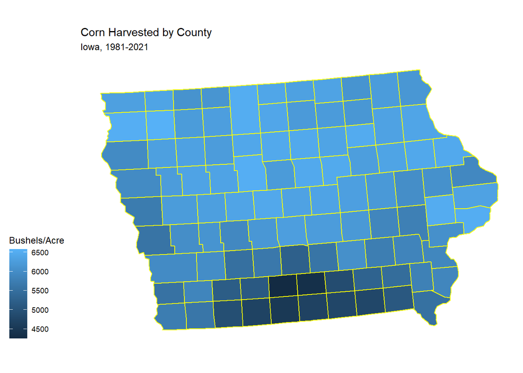

```r
#Creating map using usmap package and library. FIPS codes are county_ansi + 19000 in Iowa
#Using total summed corn harvested over study period
corn_sum <- cornyields %>%
  group_by(county_name) %>%
  mutate(corn = sum(yield)) %>%
  distinct(county_name, .keep_all=T)
corn_sum <- subset(corn_sum, select = -c(yield, year))
corn_sum$fips <- corn_sum$county_ansi + 19000

plot_usmap(data=corn_sum, values="corn", include="IA", color="yellow") +
  scale_fill_continuous(name="Bushels/Acre") +
  labs(title="Corn Harvested by County", subtitle="Iowa, 1981-2021") +
  theme(legend.position = "left")
```

### Bonus #2: Challenge question

Map trends in corn yields by county across Iowa. Interpret your map.

### Bonus Answer 2

What we see in the above map, which sums total corn harvested across the 1981-2021 study period, is that the highest yield of corn is in the north-central part of the state. The lowest corn yield occurs along the southern border with Missouri, while the western border along South Dakota and Nebraska is another low-yield area. I was surprised that the counties containing Des Moines and Cedar Rapids did not have lower yields.

An additional useful metric would be to convert this into total bushels of corn instead of its current density unit of bushels/acre.